# Groundwater Depletion Grids

Tejasvi Hora

2022-10-31

## Introduction

This assessment relies on:

- Downscaled GRACE data-provided by **Prof. Di Long, Li Chen and Ximing Wang.**
- Non-downscaled GRACE data processed by Tejasvi Hora

The purpose of this report is to:

- Calculate the GRACE Groundwater Drought Index (GGDI) – 10.1016/j.rse.2017.06.026
- Create a binary grid highlighting regions with and without depletion

## Load and pre-process the datasets

Main steps involved:

- Loading the dataset: `GWS_mean_05deg.nc`
- Linking points with World Bank regions data

## Trend Analysis (Downscaled)

*Reference to Previous Analysis*

The steps involved in assessing trends were:

- Conversion of monthly GWS estimates to annual
- Estimating *linear* trends by estimating Sen’s Slope
- Significance of trend not assessed

### MENA

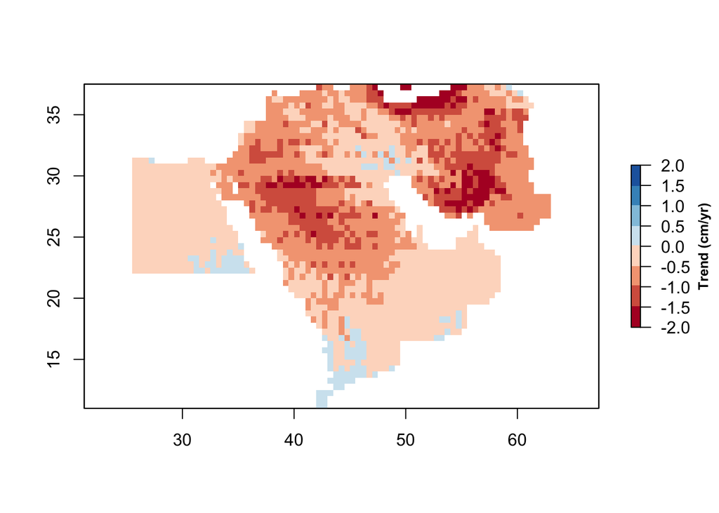

### SSA

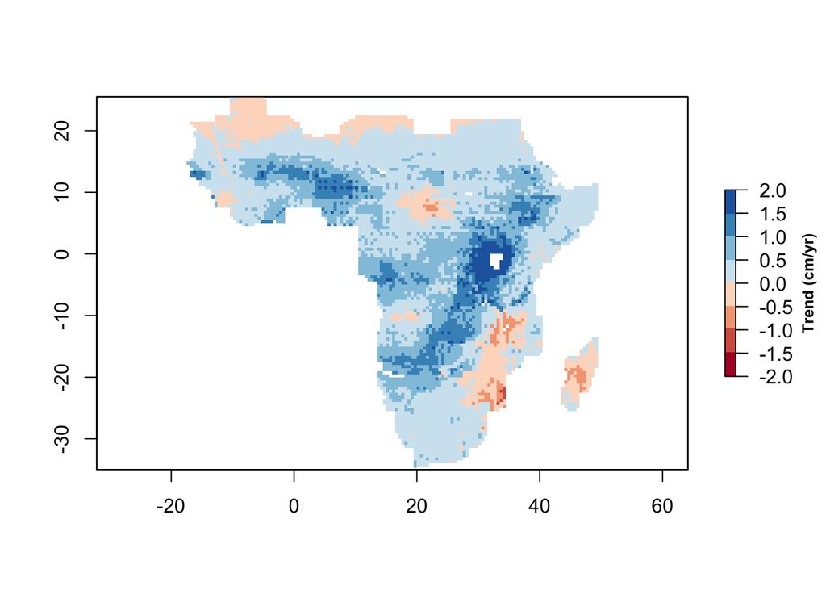

### SA

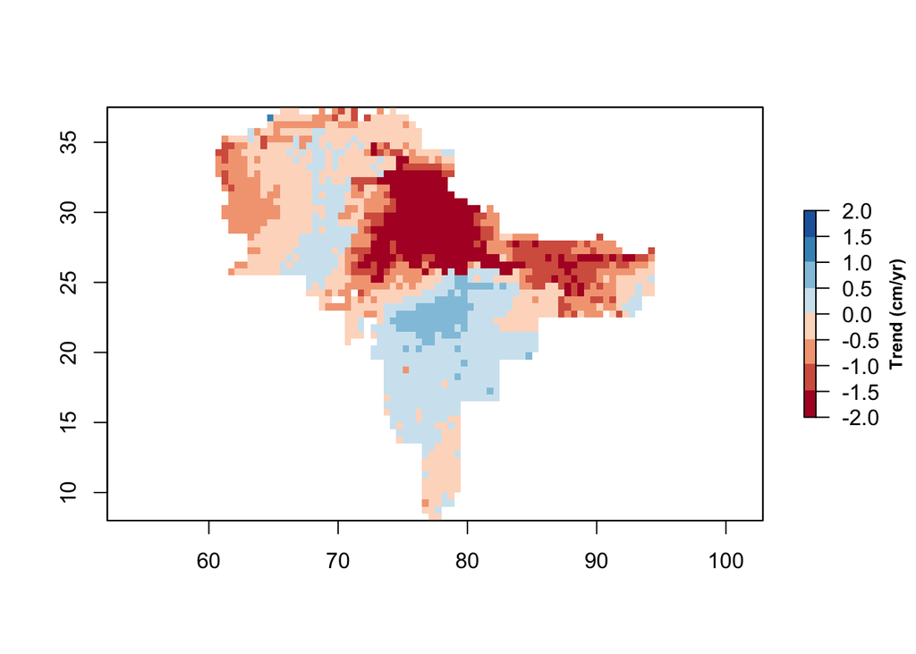

## Groundwater Deficit Indicator (Downscaled)

**See the paper here for more details: https://www.sciencedirect.com/science/article/abs/pii/S0034425717302869**

Reading the map:

- Red are regions with values = 1 – regions where GW storage has declined based on the indicator
- Blue are regions with values = 0 – regions where GW storage has not declined based on the indicator

### Eg. No depletion

**Check values towards the end of the time series**

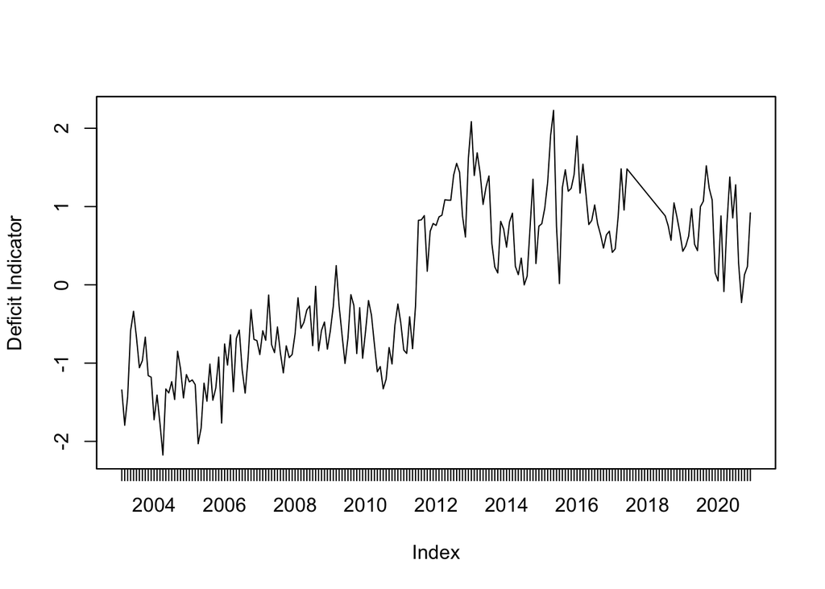

### Eg. With depletion

**Check values towards the end of the time series**

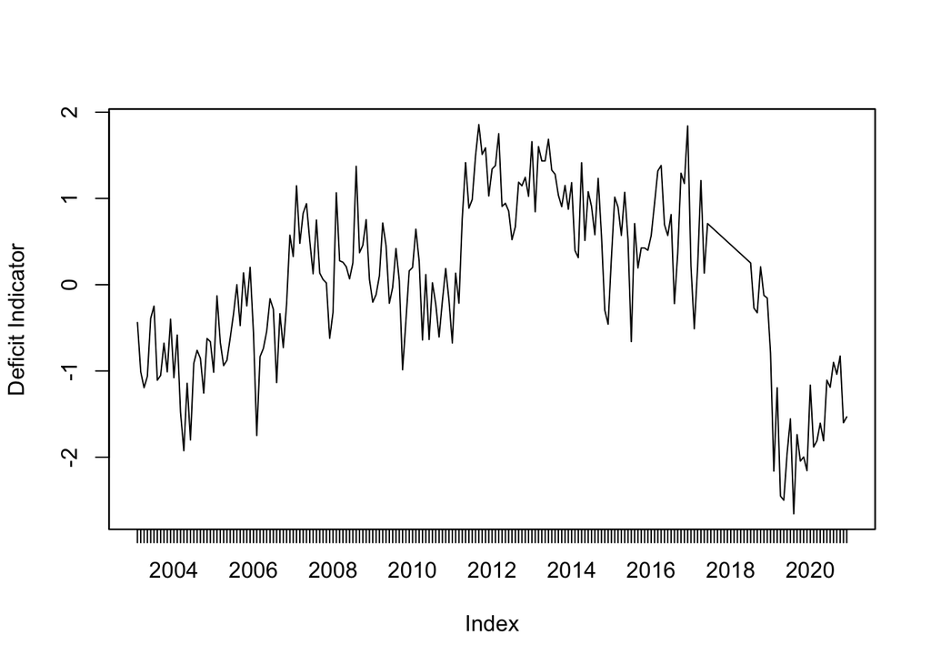

### MENA

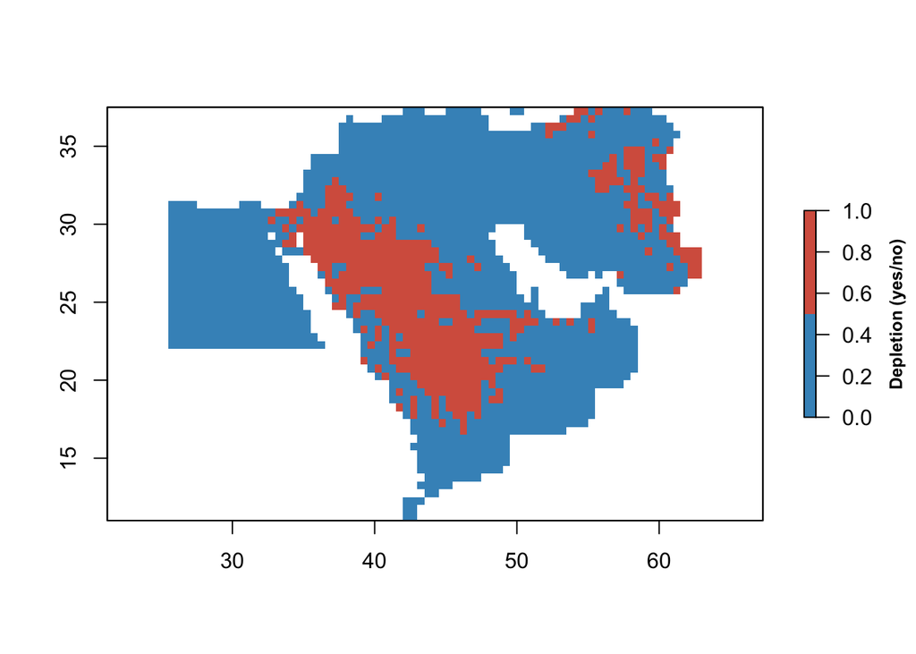

### SSA

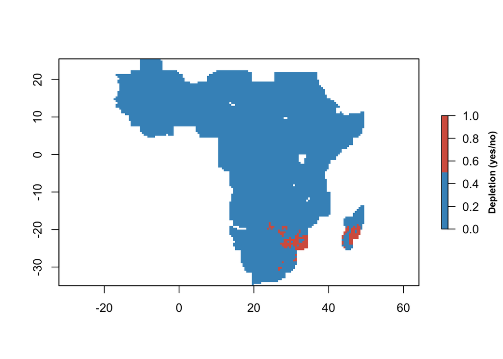

### SA

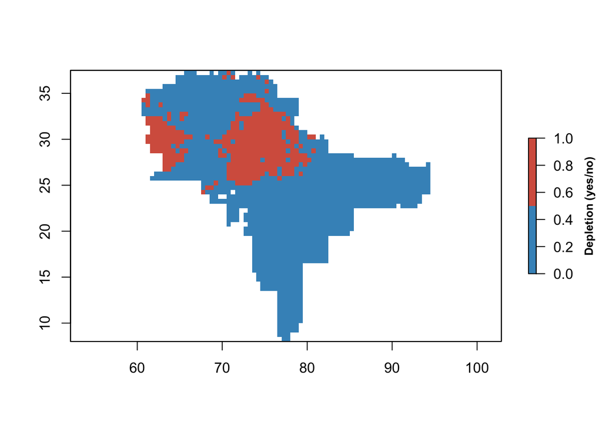

## Groundwater Deficit Indicator (Non-Downscaled)

- Follows the same methodology as the above.
- Uses the 3 by 3 degrees GRACE grid

Reading the map:

- Red are regions with values = 1 – regions where GW storage has declined based on the indicator
- Blue are regions with values = 0 – regions where GW storage has not declined based on the indicator

### Eg. With depletion

**Check values towards the end of the time series**

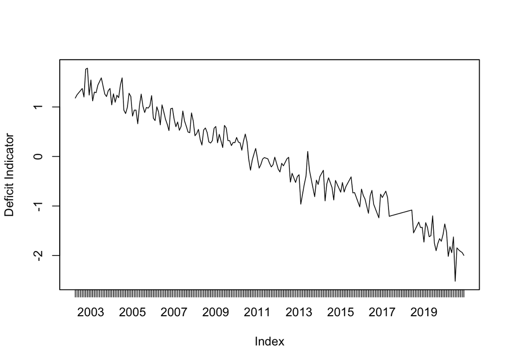

### Global Hotspots

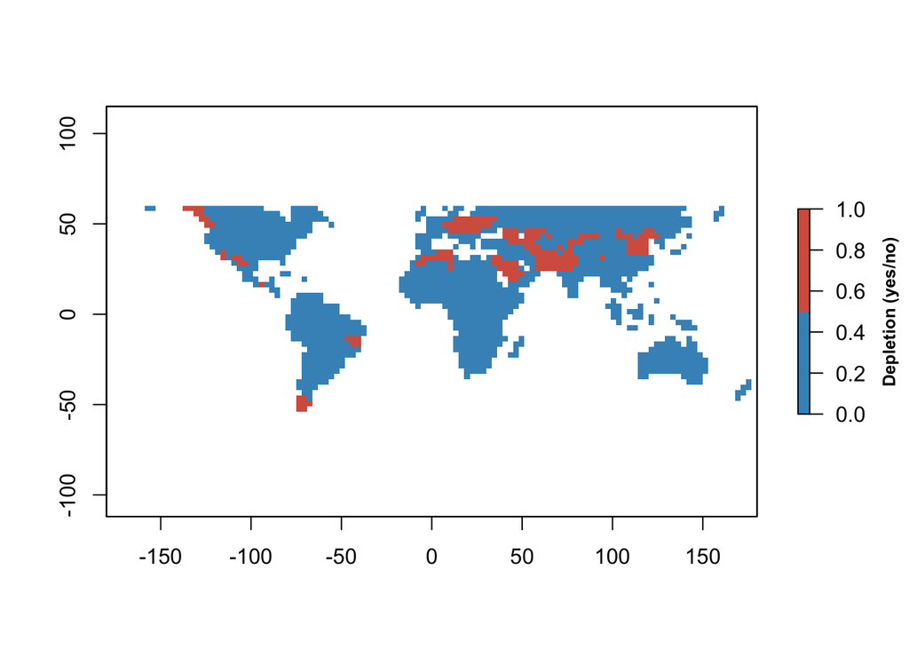